# PROJECT ON CENSUS INCOME DATASET

# Table of Contents

1. Objective
2. Exploratory Data Analysis
1. Summary of Dataset
2. Cleaning Data
3. Univariate Distribution
- Conclusion-Univariate Distribution
4. Bivariate Distribution
- Conclusion-Bivariate Distribution
5. Multivariate Distibution
- Conclusion-Multivariate Distribution
3. Predictive Modeling
- Logistic Regression Model
- Decision Tree Model
- Random Forest Model
4. Conclusion

# Objective

In this project, we will use the US census data to build a model to predict if the income of any individual in the US is greater than or less than USD 50000 based on the information available about that individual in the census data.

The dataset used for the analysis is an extraction from the 1994 census data by Barry Becker and donated to the public site http://archive.ics.uci.edu/ml/datasets/Census+Income. This dataset is popularly called the “Adult” data set. We will use different visualization techniques to conduct a preliminary analysis of the impact of different variables on each other and finally we will predict whether a person makes over 50K a year.

# Exploratory Data Analysis

### Reading the Dataset

```r
adult <- read.csv("C:/Users/u22v05/Desktop/dataset/adult.txt", header=FALSE)
adult <- setNames(adult,c("age","Workclass","fnlwgt","education","educationnum","maritalstatus","occupation","relationship","race","sex","capitalgain","capitalloss","hoursperweek","nativecountry","salary")) #changing column names for convinience
```

### Loading necessary packages for this analysis:

```r
library(ggplot2)
library(plyr)
library(dplyr)
library(tidyr)
library(corrplot)
library(descr)
library(knitr)
```

### Data Description

```r
dim(adult)[1]
```

```
## [1] 32561
```

- This indicates that the total number of records in the file “adult.data” is 32561.

```r
dim(adult)[2]
```

```
## [1] 15
```

- Originally in the adult data set there are 14 attributes but here we have included 15th attribute which is salary which describes whether the salary is >50k or not.

```r
str(adult)
```

```
## 'data.frame':    32561 obs. of  15 variables:
##  $ age          : int  39 50 38 53 28 37 49 52 31 42 ...
##  $ Workclass    : Factor w/ 9 levels " ?"," Federal-gov",..: 8 7 5 5 5 5 5 7 5 5 ...
##  $ fnlwgt       : int  77516 83311 215646 234721 338409 284582 160187 209642 45781 159449 ...
##  $ education    : Factor w/ 16 levels " 10th"," 11th",..: 10 10 12 2 10 13 7 12 13 10 ...
##  $ educationnum : int  13 13 9 7 13 14 5 9 14 13 ...
##  $ maritalstatus: Factor w/ 7 levels " Divorced"," Married-AF-spouse",..: 5 3 1 3 3 3 4 3 5 3 ...
##  $ occupation   : Factor w/ 15 levels " ?"," Adm-clerical",..: 2 5 7 7 11 5 9 5 11 5 ...
##  $ relationship : Factor w/ 6 levels " Husband"," Not-in-family",..: 2 1 2 1 6 6 2 1 2 1 ...
##  $ race         : Factor w/ 5 levels " Amer-Indian-Eskimo",..: 5 5 5 3 3 5 3 5 5 5 ...
##  $ sex          : Factor w/ 2 levels " Female"," Male": 2 2 2 2 1 1 1 2 1 2 ...
##  $ capitalgain  : int  2174 0 0 0 0 0 0 0 14084 5178 ...
##  $ capitalloss  : int  0 0 0 0 0 0 0 0 0 0 ...
##  $ hoursperweek : int  40 13 40 40 40 40 16 45 50 40 ...
##  $ nativecountry: Factor w/ 42 levels " ?"," Cambodia",..: 40 40 40 40 6 40 24 40 40 40 ...
##  $ salary       : Factor w/ 2 levels " <=50K"," >50K": 1 1 1 1 1 1 1 2 2 2 ...
```

### Input variables in the dataset are:

[output not shown]

#### Detailed Description of variables:

1. **age:**the age of an individual- Continuous.(numeric)
2. **workclass:** a term to represent the employment status of an individual:Private, Self-emp-not-inc(Self employed not incorporated-Refers to people who work for themselves in corporate entities.), Self-emp-inc(Self employed incorporated-Refers to people who work for themselves in corporate entities.), Federal-gov(Federal Government), Local-gov(local government), State-gov(State Government), Without-pay, Never-worked.(Categorical)
3. **fnlwgt(final weight):**In other words, this is the number of people the census believes the entry represents..-Continuous.(numeric)
4. **education:** The highest level of education achieved by an individual:Bachelors, Some-college, 11th, HS-grad(High School Graduate), Prof-school(Professional school), Assoc-acdm(Associates degree-academic program), Assoc-voc(Associates degree-vocational), 9th, 7th-8th, 12th, Masters, 1st-4th, 10th, Doctorate, 5th-6th, Preschool.(Categorical)
5. **education-num:**Number of years of education in total,which is a continuous representation of the variable education(Continuous)
6. **maritalstatus:**Marital status of an individual. Married-civ-spouse corresponds to a civilian spouse while Married-AF-spouse is a spouse in the Armed Forces.- Married-civ-spouse, Divorced, Never-married, Separated, Widowed, Married-spouse-absent, Married-AF-spouse.(Categorical)
7. **occupation:** the general type of occupation of an individual: Tech-support(Techinical support), Craft-repair(Does not require high education,just repairing works), Other-service, Sales, Exec-managerial(Executive manager), Prof-specialty(Speciality in a particular profession), Handlers-cleaners, Machine-op-inspct(Machine operator inspector), Adm-clerical(Admin Clerical), Farming-fishing, Transport-moving, Priv-house-serv(Private house servant), Protective-serv(Protective Servant), Armed-Forces(Working in army).(Categorical)
8. **relationship:**represents what this individual is relative to others- Wife, Own-child, Husband, Not-in-family, Other-relative, Unmarried.(Categorical)
9. **race:**Descriptions of an individual’s race- White, Asian-Pac-Islander, Amer-Indian-Eskimo, Other, Black.(Categorical)
10. **sex:** the biological sex of the individual- Female, Male.(Categorical)
11. **capitalgain:**(income from investment sources other than salary) Continuous.(numeric)
12. **capitalloss:**(income from investment sources other than salary) Continuous.(numeric)
13. **hoursperweek:**(Total number of hours a person work in week ) Continuous.(numeric)
14. **nativecountry:**Country of origin of the participant: United-States, Cambodia, England, Puerto-Rico, Canada, Germany, Outlying-US(Guam-USVI-etc), India, Japan, Greece, South, China, Cuba, Iran, Honduras, Philippines, Italy, Poland, Jamaica, Vietnam, Mexico, Portugal, Ireland, France, Dominican-Republic, Laos, Ecuador, Taiwan, Haiti, Columbia, Hungary, Guatemala, Nicaragua, Scotland, Thailand, Yugoslavia, El-Salvador, Trinadad&Tobago, Peru, Hong, Holand-Netherlands.(Categorical)
15. **salary:**whether salary is >50K or <=50K per year?- >50K ,<=50K(Categorical)

## Summary of Dataset

```r
summary(adult) #summary of dataset
```

```
##       age                    Workclass         fnlwgt
##  Min.   :17.00    Private         :22696   Min.   :  12285
##  1st Qu.:28.00    Self-emp-not-inc: 2541   1st Qu.: 117827
##  Median :37.00    Local-gov       : 2093   Median : 178356
##  Mean   :38.58    ?               : 1836   Mean   : 189778
##  3rd Qu.:48.00    State-gov       : 1298   3rd Qu.: 237051
##  Max.   :90.00    Self-emp-inc    : 1116   Max.   :1484705
##                  (Other)          :  981
##          education      educationnum                  maritalstatus
##   HS-grad     :10501   Min.   : 1.00    Divorced             : 4443
##   Some-college: 7291   1st Qu.: 9.00    Married-AF-spouse    :   23
##   Bachelors   : 5355   Median :10.00    Married-civ-spouse   :14976
##   Masters     : 1723   Mean   :10.08    Married-spouse-absent:  418
##   Assoc-voc   : 1382   3rd Qu.:12.00    Never-married        :10683
##   11th        : 1175   Max.   :16.00    Separated            : 1025
##  (Other)      : 5134                    Widowed              :  993
##             occupation            relationship
##   Prof-specialty :4140    Husband       :13193
##   Craft-repair   :4099    Not-in-family : 8305
##   Exec-managerial:4066    Other-relative:  981
##   Adm-clerical   :3770    Own-child     : 5068
##   Sales          :3650    Unmarried     : 3446
##   Other-service  :3295    Wife          : 1568
##  (Other)         :9541
##                   race            sex         capitalgain
##   Amer-Indian-Eskimo:  311    Female:10771   Min.   :    0
##   Asian-Pac-Islander: 1039    Male  :21790   1st Qu.:    0
##   Black             : 3124                   Median :    0
##   Other             :  271                   Mean   : 1078
##   White             :27816                   3rd Qu.:    0
##                                              Max.   :99999
##
##   capitalloss      hoursperweek          nativecountry      salary
##  Min.   :   0.0   Min.   : 1.00    United-States:29170    <=50K:24720
##  1st Qu.:   0.0   1st Qu.:40.00    Mexico       :  643    >50K : 7841
##  Median :   0.0   Median :40.00    ?            :  583
##  Mean   :  87.3   Mean   :40.44    Philippines  :  198
##  3rd Qu.:   0.0   3rd Qu.:45.00    Germany      :  137
##  Max.   :4356.0   Max.   :99.00    Canada       :  121
##                                   (Other)       : 1709
```


## CLEANING DATA

```r
library(tidyr)
#There are some missing valus in given dataset so we are replacing these missing values with NAs
idx <- adult == " ?"   #finding out '?' in dataset and replacing them with NA
is.na(adult) <- idx
colSums(is.na(adult))  #finding out number of NA
```

```
##           age     Workclass        fnlwgt     education  educationnum
##             0          1836             0             0             0
## maritalstatus    occupation  relationship          race           sex
##             0          1843             0             0             0
##   capitalgain   capitalloss  hoursperweek nativecountry        salary
##             0             0             0           583             0
```

- From the above table we can see that there are 1836 missing values in Workclass variable ,1843 missing values in Occupation variable and 583 missing values in Native country column.
- Here we have NAs present in 3 categorical variables.It is neccessary to treat the missing values because some classification algorithm will fail if they are passed with data containing missing values.
- Treating NAs :We can treat NAs in the following ways.
1. DROPPING NULL OR MISSING VALUES-This is the fastest and easiest step to handle missing values. However, it is not generally advised. This method reduces the quality of our model as it reduces sample size because it works by deleting all other observations where any of the variable is missing.
2. FILL MISSING VALUES WITH TEST STATISTIC-This is the most common method of handling missing values. This is a process whereby missing values are replaced with a test statistic like mean, median or mode of the particular feature the missing value belongs to.For categorical variables,we can replace missing values by frequently occuring value in that column.
3. PREDICTIVE MODEL FOR HANDLING MISSING DATA-Depending on the class of data that is missing, one can either use a regression model or classification to predict missing data. This works by turning missing features to labels themselves and now using columns without missing values to predict columns with missing values.

```r
Mode <- function(x) {
  ux <- unique(x)
  ux[which.max(tabulate(match(x, ux)))]
}
adult <- lapply(adult, function(x) {
    if(is.factor(x)) replace(x, is.na(x), Mode(na.omit(x)))
    else if(is.numeric(x)) replace(x, is.na(x), mean(x, na.rm=TRUE))
    else x
})
adult <- as.data.frame(adult)
colSums(is.na(adult))
```

```
##           age     Workclass        fnlwgt     education  educationnum
##             0             0             0             0             0
## maritalstatus    occupation  relationship          race           sex
##             0             0             0             0             0
##   capitalgain   capitalloss  hoursperweek nativecountry        salary
##             0             0             0             0             0
```

- Replaced missing values with frequently occuring value of that variable not with mean value because NAs are present in categorical variable and we cannot find it’s mean and omiting NAs will reduce size of data.

## Univariate Distribution

### Analysis of variable “Salary”

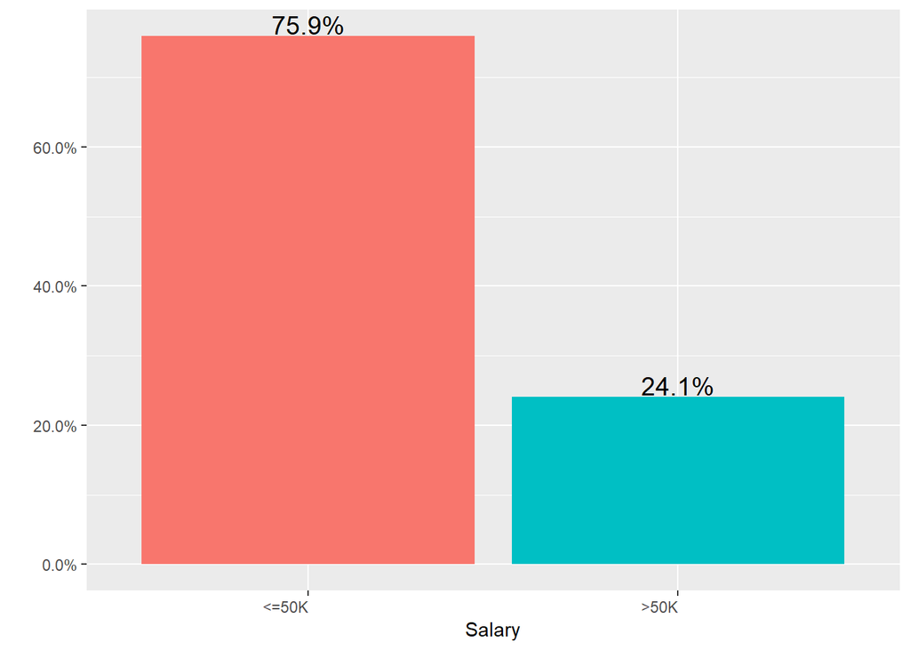

```r
library(scales)

ggplot(adult,aes(x = adult$salary, fill = adult$salary)) +geom_bar(aes(y = (..count..)/sum(..count..))) +
  geom_text(aes(label = scales::percent((..count..)/sum(..count..)),y = (..count..)/sum(..count..) ), stat = "count", vjust = -.1,size=5) +labs(x = "Salary",  y = "",fill = "Salary") +theme(legend.position = 'none',axis.text.x = element_text( hjust = 1)) + scale_y_continuous(labels = percent)
```

- The graph above shows us that 75.9% of people earn less than or equal to 50k means the data is unbalanced and we may get biased results that salary is usually less than or equal to 50k.

### Analysis of variable “Age”

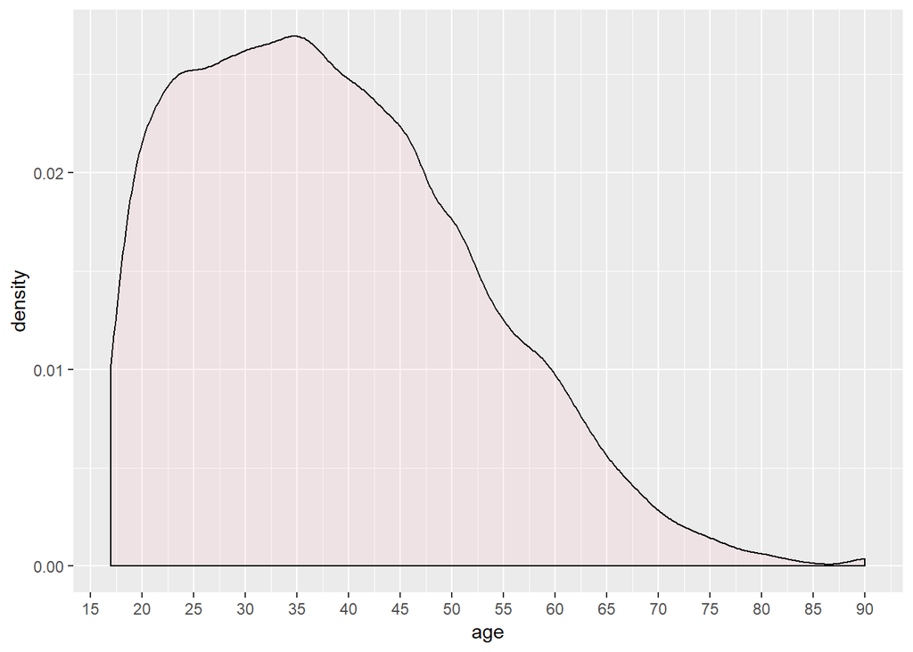

```r
ggplot(data =adult, aes(age)) +
  geom_density(alpha = 0.2,fill="pink") +
  scale_x_continuous(breaks = seq(0, 95, 5))
```

- Above graph shows that majority of working population lies in the age group of 20 to 50 years this situation is reasonable in reality beacause working age of people lies in this range only.As the age increases after 37 years there is decrease in working class people.There are some outliers, such as individuals who are 77 years or above are also earning either by capital gain or by working.

```r
aduage <- select(adult,age)
aduage2 <- filter(aduage,age>27 & age<47)
count(aduage2)
```

```
## # A tibble: 1 x 1
##       n
##   <int>
## 1 15640
```

- Above count clearly shows us maximum participants are of age 27 to 47 years.

### Analysis of variable “Work class”

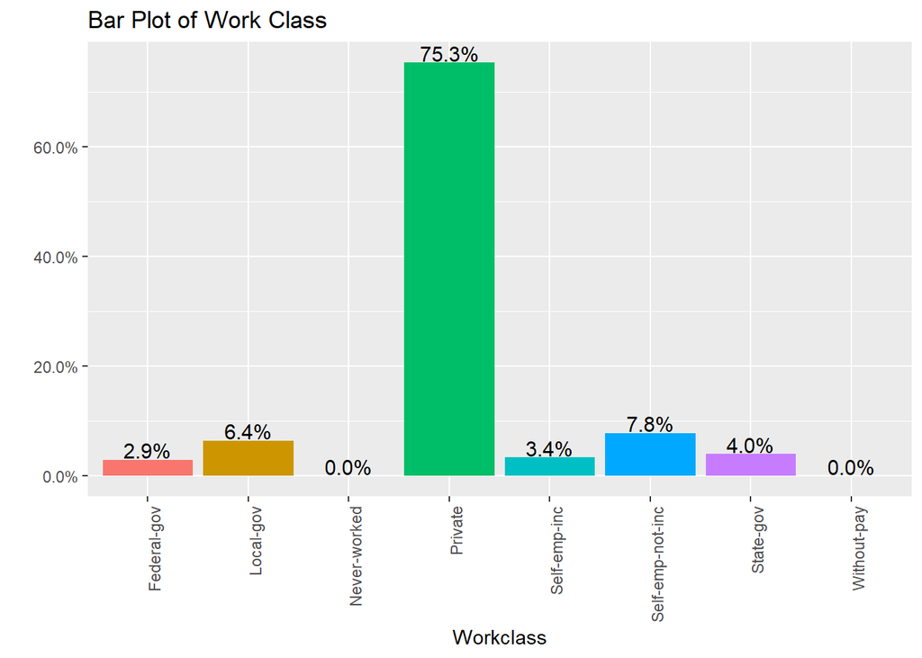

```r
ggplot(adult,aes(x = adult$Workclass, fill = adult$Workclass)) +geom_bar(aes(y = (..count..)/sum(..count..))) +
  geom_text(aes(label = scales::percent((..count..)/sum(..count..)),y = (..count..)/sum(..count..) ), stat = "count", vjust = -.1,size=4) +labs(x = "Workclass",  y = "",fill = "Workclass") +theme(legend.position = 'none',axis.text.x = element_text( hjust = 1, angle=90)) + scale_y_continuous(labels = percent)+ggtitle("Bar Plot of Work Class")
```

```r
table(adult$Workclass)
```

```
##
##                 ?       Federal-gov         Local-gov      Never-worked
##                 0               960              2093                 7
##           Private      Self-emp-inc  Self-emp-not-inc         State-gov
##             24532              1116              2541              1298
##       Without-pay
##                14
```

### Analysis of variable “Education”

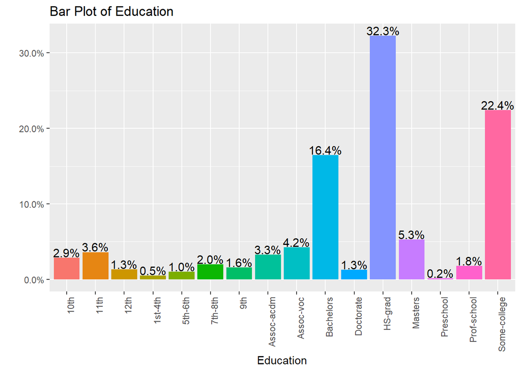

```r
ggplot(adult,aes(x = adult$education, fill = adult$education)) +geom_bar(aes(y = (..count..)/sum(..count..))) +geom_text(aes(label = scales::percent((..count..)/sum(..count..)),y = (..count..)/sum(..count..) ), stat = "count", vjust = -.1,size=4) +labs(x = "Education",  y = "",fill = "Education") +theme(legend.position = 'none',axis.text.x = element_text( hjust = 1, angle=90)) + scale_y_continuous(labels = percent)+ggtitle("Bar Plot of Education")
```

- The above barplot of Education gives the inference that the maximum number of people are High School Graduate and minimum number of participant belongs to 1st-4th class and preschool which is relatable situation because during school usually kids don’t work and after graduating from high school, students start living on their own in US.

```r
table(adult$education)
```

```
##
##          10th          11th          12th       1st-4th       5th-6th
##           933          1175           433           168           333
##       7th-8th           9th    Assoc-acdm     Assoc-voc     Bachelors
##           646           514          1067          1382          5355
##     Doctorate       HS-grad       Masters     Preschool   Prof-school
##           413         10501          1723            51           576
##  Some-college
##          7291
```

- 1175 participants are of 11th grade.
- Maximum participants are High school graduate i.e. 10501.
- 7291 participants are of some college but they don’t have a degree.
- 1382 participants holds Associates degree(vocational)
- 5355 participants hold Bachelors degree(Example-BA AB BS)
- 1723 participants holds Masters degree(Like MA MS MEng MEd MSW MBA)

### Analysis of variable “Marital Status”

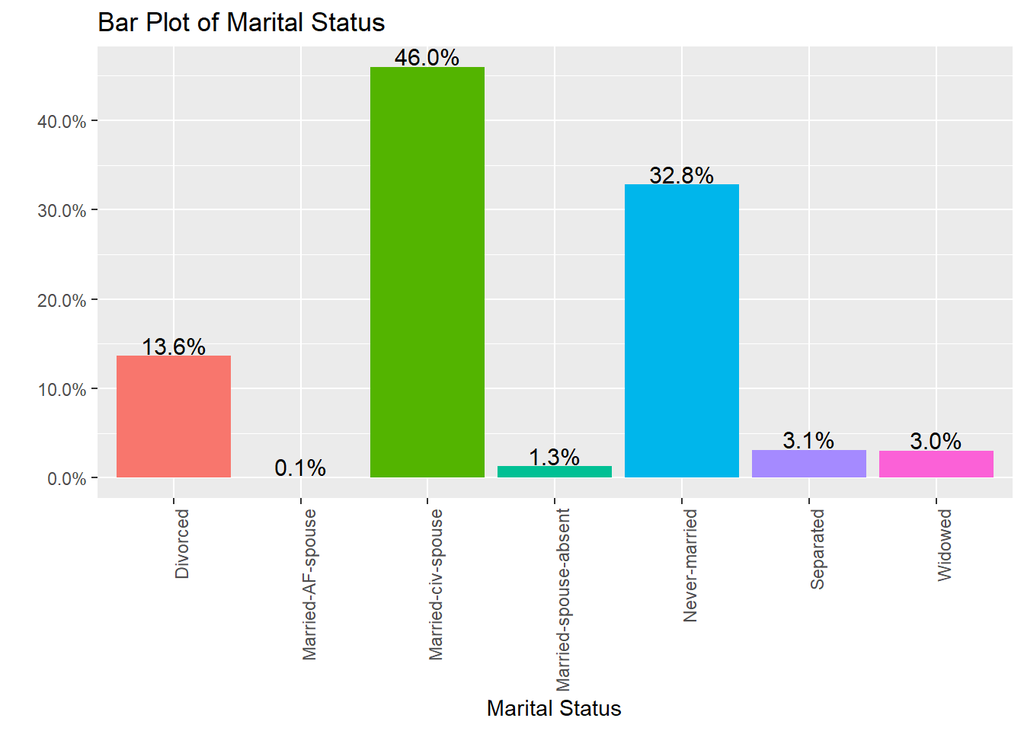

```r
ggplot(adult,aes(x = adult$maritalstatus, fill = adult$maritalstatus)) +geom_bar(aes(y = (..count..)/sum(..count..))) +
  geom_text(aes(label = scales::percent((..count..)/sum(..count..)),y = (..count..)/sum(..count..) ), stat = "count", vjust = -.1,size=4) +labs(x = "Marital Status",  y = "",fill = "Marital Status") +theme(legend.position = 'none',axis.text.x = element_text( hjust = 1, angle=90)) + scale_y_continuous(labels = percent)+ggtitle("Bar Plot of Marital Status")
```

- A person married to a civilian spouse is more likely to work as civilians are more educated and people who never married are more as these are college going or High School graduate students who were large in number.

```r
table(adult$maritalstatus)
```

```
##
##               Divorced      Married-AF-spouse     Married-civ-spouse
##                   4443                     23                  14976
##  Married-spouse-absent          Never-married              Separated
##                    418                  10683                   1025
##                Widowed
##                    993
```

- The count of people married to civilian spouse is 14976 which clearly indicates that most of the working class people are married and educated.
- 10683 people who never married are second highest in number these are college going or High School graduate students who were large in number.
- 4443 people are divorced.
- 1025 people are separated from their spouse.
- 993 people are widowed
- 418 participant’s spouse is absent.

### Analysis of variable “Occupation”

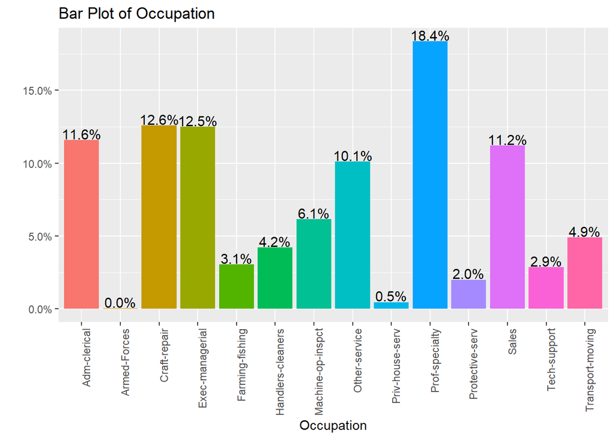

```r
ggplot(adult,aes(x = adult$occupation, fill = adult$occupation)) +geom_bar(aes(y = (..count..)/sum(..count..))) +
  geom_text(aes(label = scales::percent((..count..)/sum(..count..)),y = (..count..)/sum(..count..) ), stat = "count", vjust = -.1,size=4) +labs(x = "Occupation",  y = "",fill = "Occupation") +theme(legend.position = 'none',axis.text.x = element_text( hjust = 1, angle=90)) + scale_y_continuous(labels = percent)+ggtitle("Bar Plot of Occupation")
```

- The above graph indicates that a person who has speciality in particular profession is more in number.There is large number of people even from “craft repair” which does not require much education. Population is evenly distributed among different occupation.

```r
table(adult$occupation)
```

```
##
##                  ?       Adm-clerical       Armed-Forces
##                  0               3770                  9
##       Craft-repair    Exec-managerial    Farming-fishing
##               4099               4066                994
##  Handlers-cleaners  Machine-op-inspct      Other-service
##               1370               2002               3295
##    Priv-house-serv     Prof-specialty    Protective-serv
##                149               5983                649
##              Sales       Tech-support   Transport-moving
##               3650                928               1597
```

- Maximum people have professional speciality that is 5983.
- Participants of occupation “Admin support including clerical” is 3770
- Participants of occupation Executive admin and managerial 4066
- Participants who are in Other services are 3295
- Participants indulged in Sales are 3650
- Participants of occupation “Precision production craft & repair” is 4099

### Analysis of variable “Relationship”

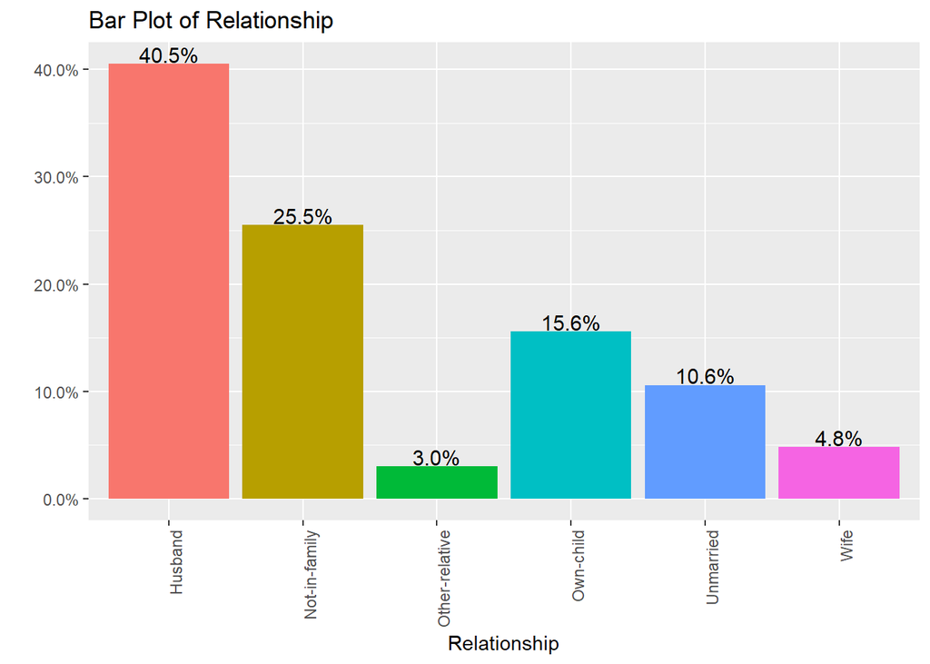

```r
ggplot(adult,aes(x = adult$relationship, fill = adult$relationship)) +geom_bar(aes(y = (..count..)/sum(..count..))) +
  geom_text(aes(label = scales::percent((..count..)/sum(..count..)),y = (..count..)/sum(..count..) ), stat = "count", vjust = -.1,size=4) +labs(x = "Relationship",  y = "",fill = "Relationship") +theme(legend.position = 'none',axis.text.x = element_text( hjust = 1, angle=90)) + scale_y_continuous(labels = percent)+ggtitle("Bar Plot of Relationship")
```

- Above graph shows that maximum participants are husbands which is reasonable as male’s working percentage is higher and usually male member has the responsibility.

```r
table(adult$relationship)
```

```
##
##         Husband   Not-in-family  Other-relative       Own-child
##           13193            8305             981            5068
##       Unmarried            Wife
##            3446            1568
```

- Majority of people are husbands that is 13193 as they are male and have responsibility of family.
- 8305 people dont have a family which is second highest.
- Participants who are wives are 1568.
- 3446 people are unmarried.
- 5068 are own-child.(Basically these are the people who are single,they maybe married or not.)
- 981 people are the “other relatives” of other people.

### Analysis of variable “Race”

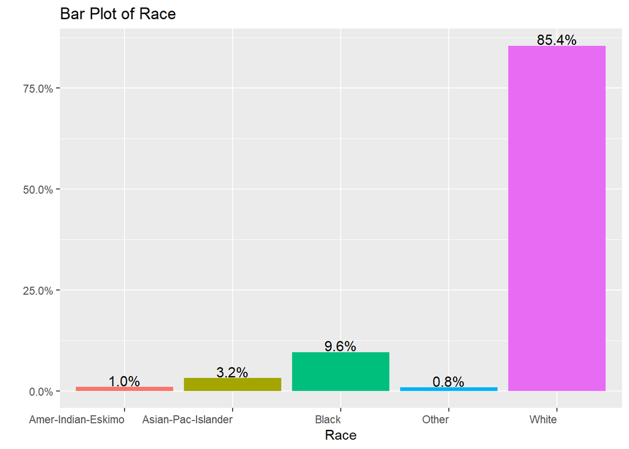

```r
ggplot(adult,aes(x = adult$race, fill = adult$race)) +geom_bar(aes(y = (..count..)/sum(..count..))) +
  geom_text(aes(label = scales::percent((..count..)/sum(..count..)),y = (..count..)/sum(..count..) ), stat = "count", vjust = -.1,size=4) +labs(x = "Race",  y = "",fill = "Race") +theme(legend.position = 'none',axis.text.x = element_text( hjust = 1)) + scale_y_continuous(labels = percent)+ggtitle("Bar Plot of Race")
```

- The major part of individuals belong to the category “White”, followed by the category “Black” . As we can see from the graph above, 85.4% of the participants in the study are “White” because Americans are usually of white race.

```r
table(adult$race)
```

```
##
##  Amer-Indian-Eskimo  Asian-Pac-Islander               Black
##                 311                1039                3124
##               Other               White
##                 271               27816
```

- 27816 people out of 32561 are of white race which claerly indicated maximum people are from US and of white race.
- 3124 people are black which is second highest in number.

### Analysis of variable “Sex”

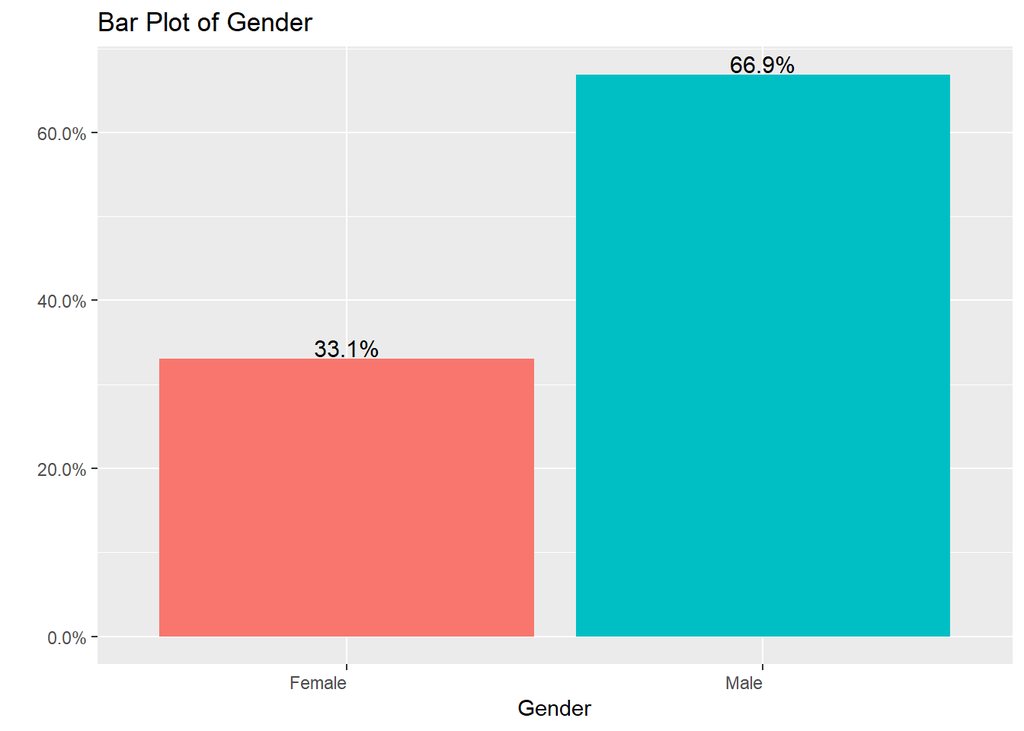

```r
ggplot(adult,aes(x = adult$sex, fill = adult$sex)) +geom_bar(aes(y = (..count..)/sum(..count..))) +
  geom_text(aes(label = scales::percent((..count..)/sum(..count..)),y = (..count..)/sum(..count..) ), stat = "count", vjust = -.1,size=4) +labs(x = "Gender",  y = "",fill = "Gender") +theme(legend.position = 'none',axis.text.x = element_text( hjust = 1)) + scale_y_continuous(labels = percent)+ggtitle("Bar Plot of Gender")
```

- 66.9% of people are male which is quite reasonable because in reality working male percentage is higher than female.

```r
table(adult$sex)
```

```
##
##  Female    Male
##   10771   21790
```

- It is clearly visible mostly working people are male that is 21790 whereas women don’t work much as they are only 10771 in number.

### Analysis of variable “capital_gain”

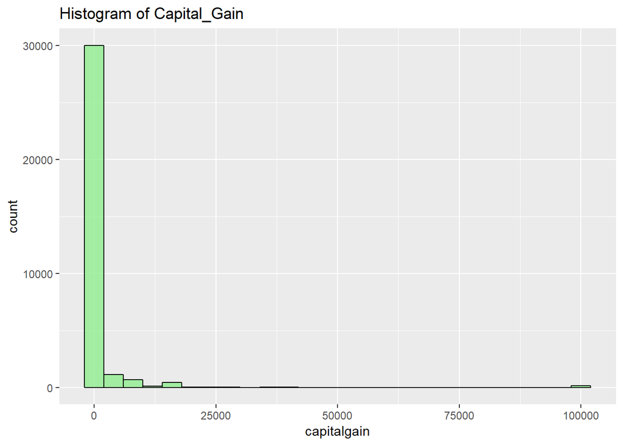

```r
ggplot(adult, mapping = aes(x = capitalgain)) + geom_histogram(binwidth = 4000,color = "black",fill = "lightgreen", alpha = 0.8)  +ggtitle("Histogram of Capital_Gain")
```

- Capital gain of most people is zero means they do not get extra profit by selling assets.Very few people make large profit by selling assets.

### Analysis of variable “capital_loss”

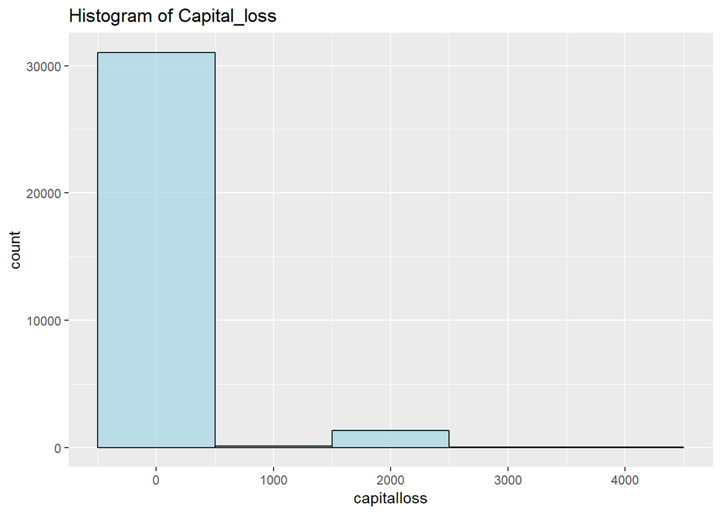

```r
ggplot(adult, mapping = aes(x = capitalloss)) + geom_histogram(binwidth = 1000,color = "black",fill = "lightblue", alpha = 0.8)  +ggtitle("Histogram of Capital_loss ")
```

- Capital loss of most people is zero means they don’t have extra loss by selling assets.Very few people had extra loss by selling assets.

### Analysis of variable “hours_per_week”

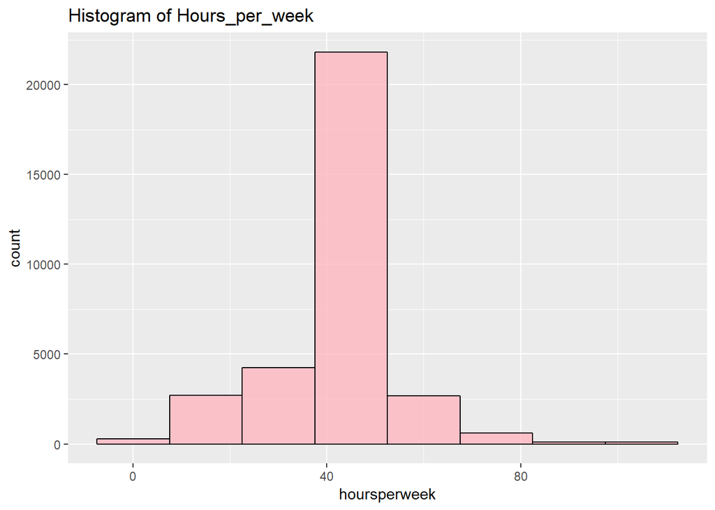

```r
ggplot(adult, mapping = aes(x = hoursperweek)) + geom_histogram(binwidth = 15,color = "black",fill = "lightpink", alpha = 0.8)  +ggtitle("Histogram of Hours_per_week ")
```

- Most of the people works for 40hours a week which is in accordance with reality as people work for 8 hours in 5 days a week.Also there are people who work for very few hours but still earn and there are people who work for more than 50 hours as well.

```r
summary(adult$hoursperweek)
```

```
##    Min. 1st Qu.  Median    Mean 3rd Qu.    Max.
##    1.00   40.00   40.00   40.44   45.00   99.00
```

- On an average peopele work for 40.44 hours per week.
- Minimum working hour per week is 1.
- Maximum working per week is 99 hours.
- 25% of people work for 40 hours as the first quadrant and median are same.
- 75% of the population works for 45 hours or less.

### Analysis of variable Native country

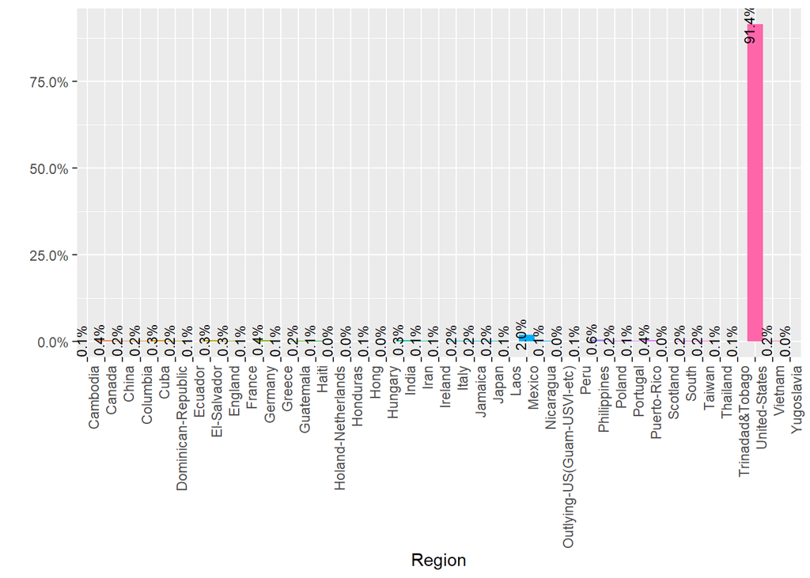

```r
ggplot(adult,aes(x = adult$nativecountry, fill = adult$nativecountry)) +geom_bar(aes(y=(..count..)/sum(..count..))) + geom_text(aes(label = scales::percent((..count..)/sum(..count..)), y = (..count..)/sum(..count..) ), stat = "count", vjust = -.1,size=3,angle=90) +labs(x = "Region", y = "",fill = "Regions") +theme(legend.position = 'none',axis.text.x = element_text(angle = 90, hjust = 1)) +  scale_y_continuous(labels = percent)
```

- The majority of people come from the United States that is 91.4% which is likely to happen as this survey is conducted in US only.

```r
table(adult$nativecountry)
```

```
##
##                           ?                    Cambodia
##                           0                          19
##                      Canada                       China
##                         121                          75
##                    Columbia                        Cuba
##                          59                          95
##          Dominican-Republic                     Ecuador
##                          70                          28
##                 El-Salvador                     England
##                         106                          90
##                      France                     Germany
##                          29                         137
##                      Greece                   Guatemala
##                          29                          64
##                       Haiti          Holand-Netherlands
##                          44                           1
##                    Honduras                        Hong
##                          13                          20
##                     Hungary                       India
##                          13                         100
##                        Iran                     Ireland
##                          43                          24
##                       Italy                     Jamaica
##                          73                          81
##                       Japan                        Laos
##                          62                          18
##                      Mexico                   Nicaragua
##                         643                          34
##  Outlying-US(Guam-USVI-etc)                        Peru
##                          14                          31
##                 Philippines                      Poland
##                         198                          60
##                    Portugal                 Puerto-Rico
##                          37                         114
##                    Scotland                       South
##                          12                          80
##                      Taiwan                    Thailand
##                          51                          18
##             Trinadad&Tobago               United-States
##                          19                       29753
##                     Vietnam                  Yugoslavia
##                          67                          16
```

- Native country of maximum poeple is US.

## Conclusion from Analysis of Univariate Distribution

### Correlation between numerical variable

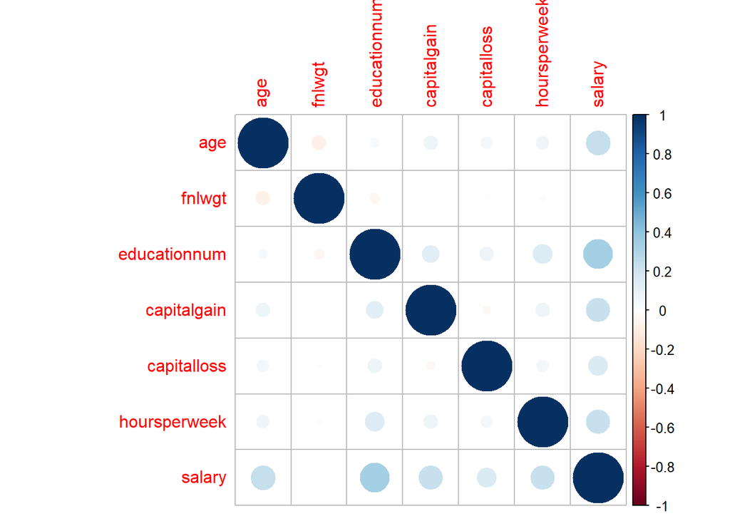

```r
adult$salary <- as.numeric(adult$salary)-1  #Changing salary to 0, 1
#Correlation plot
var <- c(1, 3, 5, 11:13, 15)
corrplot(cor(adult[,var]))
```

```r
cor(adult[,var])
```

```
##                      age        fnlwgt educationnum   capitalgain
## age           1.00000000 -0.0766458679   0.03652719  0.0776744982
## fnlwgt       -0.07664587  1.0000000000  -0.04319463  0.0004318858
## educationnum  0.03652719 -0.0431946327   1.00000000  0.1226301147
## capitalgain   0.07767450  0.0004318858   0.12263011  1.0000000000
## capitalloss   0.05777454 -0.0102517117   0.07992296 -0.0316150630
## hoursperweek  0.06875571 -0.0187684906   0.14812273  0.0784086154
## salary        0.23403710 -0.0094625572   0.33515395  0.2233288182
##              capitalloss hoursperweek       salary
## age           0.05777454   0.06875571  0.234037103
## fnlwgt       -0.01025171  -0.01876849 -0.009462557
## educationnum  0.07992296   0.14812273  0.335153953
## capitalgain  -0.03161506   0.07840862  0.223328818
## capitalloss   1.00000000   0.05425636  0.150526312
## hoursperweek  0.05425636   1.00000000  0.229689066
## salary        0.15052631   0.22968907  1.000000000
```

```r
adult$salary <- factor(adult$salary, labels=c("<=50k", ">50k")) #Re-factoring salary
```

- We can see that the numerical variables do not seem to be strongly correlated with each other. We see that the final weight variable does not appear to have an association with the response either.So we will not consider final weight.
- There is low positive correlation between age and salary means as age increases salary also increases.
- There is low positive correlation between education number and salary means as education number increases salary also increases , if a person has studied for more years earns more.
- Capital gain and salary are slightly correlated as salary increases capital gain increases because people with more salary are likely to invest more.
- Capital loss and salary are slightly correlated as salary increases capital loss may increases because people with more salary are likely to invest more so there maybe some chances of loss.
- There is low positive correlation between hours per week and salary means as hours per week increases salary also increases , if a person works for more hours earns more.

Go to top:Table of Contents

## Bivariate Distribution

### Analysis of age and salary

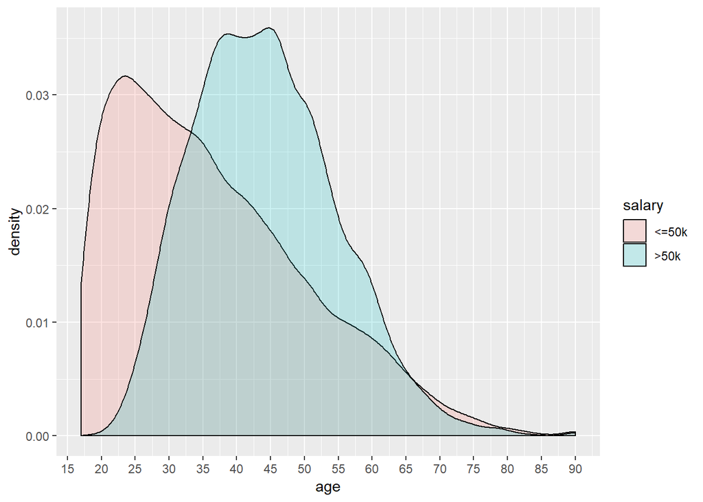

```r
ggplot(data =adult, aes(age, fill = salary)) +
  geom_density(alpha = 0.2) +
  scale_x_continuous(breaks = seq(0, 95, 5))
```

- The above density plot shows us that during the age of 20 to 35 years more people earn <50k whereas in the interval of 37 to 55 years more people earn >50k and then people earning >50k starts decreasing as they move towards the age of retirement.

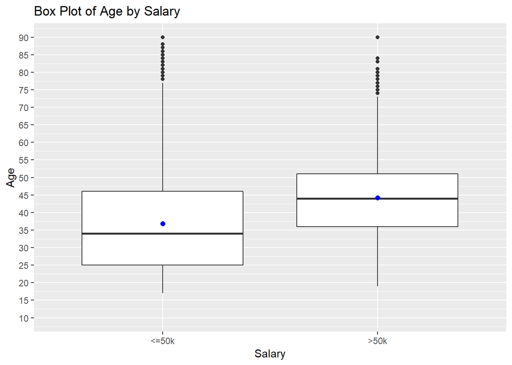

```r
ggplot(aes(x = salary, y = age),data = adult) +  geom_boxplot() + stat_summary(fun.y = mean, geom = "point",shape = 16,cex = 2,col = "blue") +coord_cartesian(ylim = c(10,90))+scale_y_continuous(breaks = seq(10, 90, 5)) + ylab("Age") +xlab("Salary") +ggtitle("Box Plot of Age by Salary")
```

```r
library(ggplot2)
summary(subset(adult$age,adult$salary== "<=50k"))
```

```
##    Min. 1st Qu.  Median    Mean 3rd Qu.    Max.
##   17.00   25.00   34.00   36.78   46.00   90.00
```

```r
summary(subset(adult$age,adult$salary== ">50k"))
```

```
##    Min. 1st Qu.  Median    Mean 3rd Qu.    Max.
##   19.00   36.00   44.00   44.25   51.00   90.00
```

- From the above summary we notice that the first quartiles (25-th percentiles) for both groups differ significantly. The 25% of people who have an income of more than 50K is equal to 36, whereas the 25% of people earning less than 50K equals 25. This means that the older an individual is, the bigger their chances of having a higher income are because income increases with experience.

### t test

- Alternative Hypothesis- The average age of people is different in the >50K and <50K samples
- Null Hypothesis- The average age of people is same in both >50K and <50K samples

```r
gr <- subset(adult$age,adult$salary== ">50k")
les <- subset(adult$age,adult$salary=="<=50k")
t.test(gr,les,paired=FALSE)
```

```
##
##  Welch Two Sample t-test
##
## data:  gr and les
## t = 50.264, df = 17411, p-value < 2.2e-16
## alternative hypothesis: true difference in means is not equal to 0
## 95 percent confidence interval:
##  7.174955 7.757250
## sample estimates:
## mean of x mean of y
##  44.24984  36.78374
```

- Conclusion-Alternative Hypothesis is true and we reject the null hypothesis means average age of people earning more than 50k is different from average age of people earning less than 50k.This shows different age group has different earnings means we will consider age as one of the features during training so it will help in prediction of salary.

### Analysis of Workclass and salary

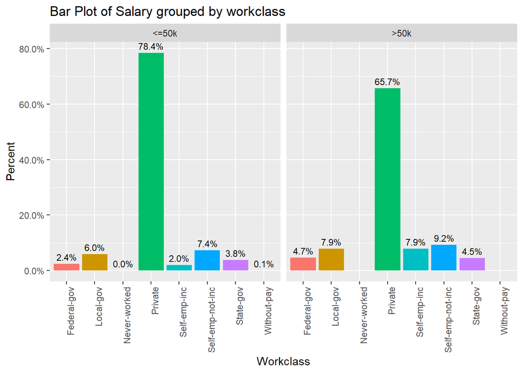

```r
ggplot(adult, aes(x= Workclass,  group=salary)) +
    geom_bar(aes(y = ..prop.., fill = factor(..x..)), stat="count") +
    geom_text(aes( label = scales::percent(..prop..),
                   y= ..prop.. ), stat= "count", vjust = -.5,size=3) +
    labs(y = "Percent", fill="Workclass") +
    facet_grid(~salary) +
    scale_y_continuous(labels = scales::percent)+theme(legend.position = 'none',axis.text.x = element_text( hjust = 1,angle=90))+ggtitle("Bar Plot of Salary grouped by workclass")
```

```r
# Number of people from different "workclass" earning less than 50K and more than 50K:
table(adult$Workclass,adult$salary)
```

```
##
##                     <=50k  >50k
##    ?                    0     0
##    Federal-gov        589   371
##    Local-gov         1476   617
##    Never-worked         7     0
##    Private          19378  5154
##    Self-emp-inc       494   622
##    Self-emp-not-inc  1817   724
##    State-gov          945   353
##    Without-pay         14     0
```

### Test for Independence of Work class and salary.

- Null Hypothesis- Workclass and salary are independent in the considered population.
- Alternate Hypothesis -Workclass and salary are dependent in the considered population.

```r
chisq.test(adult$Workclass,adult$salary,correct = FALSE)
```

```
##
##  Pearson's Chi-squared test
##
## data:  adult$Workclass and adult$salary
## X-squared = 923.6, df = 7, p-value < 2.2e-16
```

- The p-value is less than 0.05, which means that at the 0.05 significance level we fail to accept the null hypothesis that the two categorical variables are independent.Hence ,workclass and salary are dependent on eachother.So,we can use workclass as one of the feature in training for the prediction of salary.

### Analysis of Education and salary

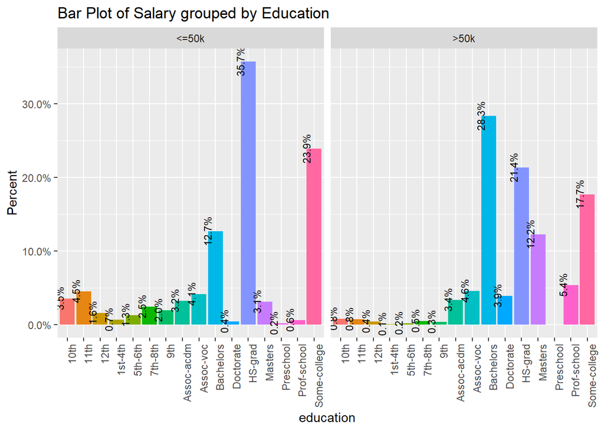

```r
ggplot(adult, aes(x=education,  group=salary)) +
    geom_bar(aes(y = ..prop.., fill = factor(..x..)), stat="count") +
    geom_text(aes( label = scales::percent(..prop..),
                   y= ..prop.. ), stat= "count", vjust = -.5,size=3,angle=90) +
    labs(y = "Percent", fill="Education") +
    facet_grid(~salary) +
    scale_y_continuous(labels = scales::percent)+theme(legend.position = 'none',axis.text.x = element_text( hjust = 1,angle=90))+ggtitle("Bar Plot of Salary grouped by Education")
```

```r
# Number of people having different education earning less than 50K and more than 50K:
table(adult$education,adult$salary)
```

```
##
##                 <=50k >50k
##    10th           871   62
##    11th          1115   60
##    12th           400   33
##    1st-4th        162    6
##    5th-6th        317   16
##    7th-8th        606   40
##    9th            487   27
##    Assoc-acdm     802  265
##    Assoc-voc     1021  361
##    Bachelors     3134 2221
##    Doctorate      107  306
##    HS-grad       8826 1675
##    Masters        764  959
##    Preschool       51    0
##    Prof-school    153  423
##    Some-college  5904 1387
```

### Test for Independence of Education and salary.

- Null Hypothesis- Education and salary are independent in the considered population.
- Alternate Hypothesis -Education and salary are dependent in the considered population.

```r
chisq.test(adult$education,adult$salary,correct = FALSE)
```

```
##
##  Pearson's Chi-squared test
##
## data:  adult$education and adult$salary
## X-squared = 4429.7, df = 15, p-value < 2.2e-16
```

- The p-value is less than 0.05, which means that at the 0.05 significance level we fail to accept the null hypothesis that the two categorical variables are independent.Hence ,Education and salary are dependent on eachother.So,we can use Education as one of the feature in training for the prediction of salary.

### Analysis of education number and salary

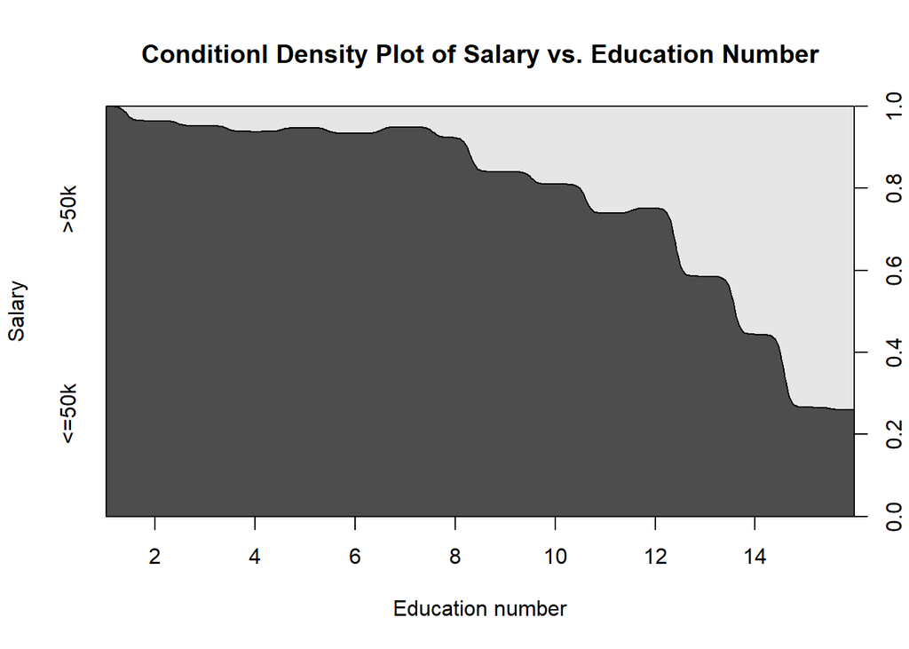

```r
library(ggplot2)
cdplot(x = adult$educationnum, y = adult$salary,xlab = "Education number", ylab = "Salary", main = "Conditionl Density Plot of Salary vs. Education Number")
```

- The conditional density plot of Salary vs. Education number shows that both are correlated,as the education number of person increases his salary also increases.When a person becomes high school graduate there is increase in number of people earning >50k.When a person gets 12 years of education there is rapid increase in number of people earning >50k.

### 1)

- Alternate Hypothesis-Average years of education for people earning >50k is more than people who are earning <=50k.
- Null Hypothesis-Average years of education for people earning >50k is not more than people who are earning <=50k.

```r
gre <- subset(adult$educationnum,adult$salary== ">50k")
less_ <- subset(adult$educationnum,adult$salary=="<=50k")
t.test(gre,less_,paired=FALSE)
```

```
##
##  Welch Two Sample t-test
##
## data:  gre and less_
## t = 64.896, df = 13421, p-value < 2.2e-16
## alternative hypothesis: true difference in means is not equal to 0
## 95 percent confidence interval:
##  1.955682 2.077502
## sample estimates:
## mean of x mean of y
## 11.611657  9.595065
```

- Conclusion-The p-value is less than 0.05, which means that at the 0.05 significance level we fail to accept the null hypothesis that average years of education for people earning >50k is not more than people who are earning <50k.If a person studies for more number of years is more likely to earn >50k.

### 2)

- Alternate Hypothesis:The increase in number of people earning >50k after passing 10th is more as compared to increase in number of people earning >50k after passing 8th.
- Null Hypothesis:The increase in number of people earning >50k after passing 10th is not more as compared to increase in number of people earning >50k after passing 8th.

```r
edu <- select(adult,educationnum)
edu <- filter(edu,educationnum >= 8 & educationnum <= 10 )
edu1 <- select(adult,educationnum)
edu1 <- filter(edu,educationnum >= 10 & educationnum <= 12 )
t.test(edu,edu1,paired = FALSE)
```

```
##
##  Welch Two Sample t-test
##
## data:  edu and edu1
## t = -158.49, df = 18224, p-value < 2.2e-16
## alternative hypothesis: true difference in means is not equal to 0
## 95 percent confidence interval:
##  -0.6314171 -0.6159903
## sample estimates:
## mean of x mean of y
##  9.376296 10.000000
```

### 3)

- Alternate Hypothesis:There is rapid increase in number of people earning >50k after passing 12th is more as compared to increase in number of people earning >50k after passing 10th.
- Null Hypothesis:The increase in number of people earning >50k after passing 12th is not more as compared to increase in number of people earning >50k after passing 10th.

```r
edu <- select(adult,educationnum)
edu <- filter(edu,educationnum >= 10 & educationnum <= 12 )
edu1 <- select(adult,educationnum)
edu1 <- filter(edu,educationnum >= 12 & educationnum <= 14)
t.test(edu,edu1)
```

```
##
##  Welch Two Sample t-test
##
## data:  edu and edu1
## t = -241.18, df = 9739, p-value < 2.2e-16
## alternative hypothesis: true difference in means is not equal to 0
## 95 percent confidence interval:
##  -1.652335 -1.625693
## sample estimates:
## mean of x mean of y
##  10.36099  12.00000
```

### Analysis of MaritalStatus and salary

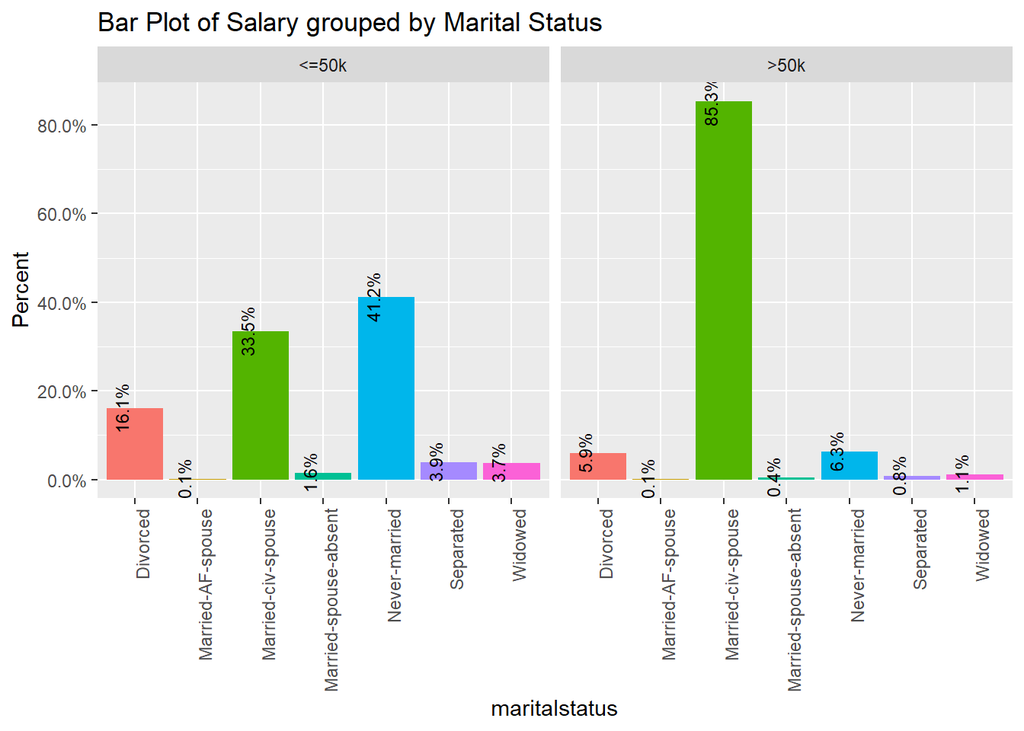

```r
ggplot(adult, aes(x=maritalstatus,  group=salary)) +
    geom_bar(aes(y = ..prop.., fill = factor(..x..)), stat="count") +
    geom_text(aes( label = scales::percent(..prop..),
                   y= ..prop.. ), stat= "count", vjust = -.5,size=3,angle=90) +
    labs(y = "Percent", fill="Marital Status") +
    facet_grid(~salary) +
    scale_y_continuous(labels = scales::percent)+theme(legend.position = 'none',axis.text.x = element_text( hjust = 1,angle=90))+ggtitle("Bar Plot of Salary grouped by Marital Status")
```

- The Barplot of Salary grouped by marital status shows that a person who has never married is likely to earn less than 50k per year whereas a person who is married to a civilian spouse is likely to earn more than 50k per year.Very few participants are married to army force spouse and 0.1% of them earn more than 50k per year as well as 0.1% earns <=50k.

```r
# Number of people having different marital status earning less than 50K and more than 50K:
table(adult$maritalstatus,adult$salary)
```

```
##
##                          <=50k  >50k
##    Divorced               3980   463
##    Married-AF-spouse        13    10
##    Married-civ-spouse     8284  6692
##    Married-spouse-absent   384    34
##    Never-married         10192   491
##    Separated               959    66
##    Widowed                 908    85
```

### Test for Independence of MaritalStatus and salary.

- Null Hypothesis- MaritalStatus and salary are independent in the considered population.
- Alternate Hypothesis -MaritalStatus and salary are dependent in the considered population.

```r
chisq.test(adult$maritalstatus,adult$salary,correct = FALSE)
```

```
##
##  Pearson's Chi-squared test
##
## data:  adult$maritalstatus and adult$salary
## X-squared = 6517.7, df = 6, p-value < 2.2e-16
```

- The p-value is less than 0.05, which means that at the 0.05 significance level we fail to accept the null hypothesis that the two categorical variables are independent.Hence ,MaritalStatus and salary are dependent on eachother.So,we can use MaritalStatus as one of the feature in training for the prediction of salary.

### Analysis of Occupation and salary

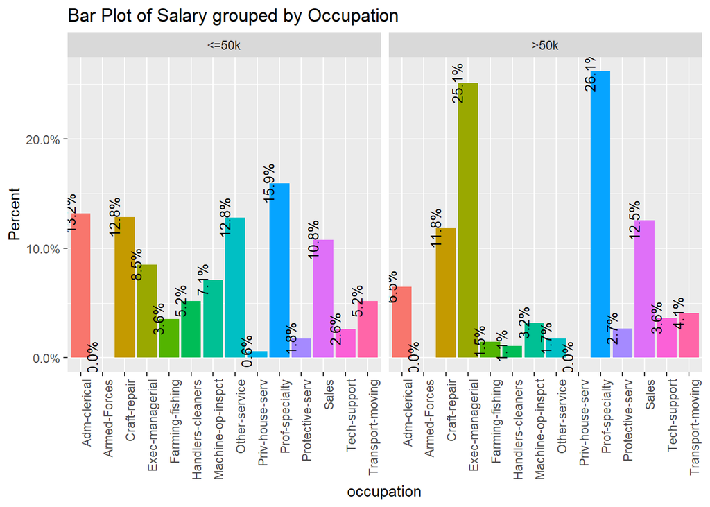

```r
ggplot(adult, aes(x=occupation,  group=salary)) +
    geom_bar(aes(y = ..prop.., fill = factor(..x..)), stat="count") +
    geom_text(aes( label = scales::percent(..prop..),
                   y= ..prop.. ), stat= "count", vjust = -.5,size=3.5,angle=90) +
    labs(y = "Percent", fill="Occupation") +
    facet_grid(~salary) +
    scale_y_continuous(labels = scales::percent)+theme(legend.position = 'none',axis.text.x = element_text( hjust = 1,angle=90))+ggtitle("Bar Plot of Salary grouped by Occupation")
```

- A participant who has speciality in a particular profession or a person who is executive manager is likely to earn more than 50k per year .Maximum number of participants who are engaged in “Pro-speciality” earns <=50k due to their less age or less number of working hours.

```r
# Number of people in different occupation earning less than 50K and more than 50K:
table(adult$occupation,adult$salary)
```

```
##
##                      <=50k >50k
##    ?                     0    0
##    Adm-clerical       3263  507
##    Armed-Forces          8    1
##    Craft-repair       3170  929
##    Exec-managerial    2098 1968
##    Farming-fishing     879  115
##    Handlers-cleaners  1284   86
##    Machine-op-inspct  1752  250
##    Other-service      3158  137
##    Priv-house-serv     148    1
##    Prof-specialty     3933 2050
##    Protective-serv     438  211
##    Sales              2667  983
##    Tech-support        645  283
##    Transport-moving   1277  320
```

### Test for Independence of Occupation and salary.

- Null Hypothesis- Occupation and salary are independent in the considered population.
- Alternate Hypothesis -Occupation and salary are dependent in the considered population.

```r
 chisq.test(adult$occupation,adult$salary,correct = FALSE)
```

```
##
##  Pearson's Chi-squared test
##
## data:  adult$occupation and adult$salary
## X-squared = 3199.8, df = 13, p-value < 2.2e-16
```

- The p-value is less than 0.05, which means that at the 0.05 significance level we fail to accept the null hypothesis that the two categorical variables are independent.Hence ,Occupation and salary are dependent on eachother.So,we can use Occupation as one of the feature in training for the prediction of salary.

### Analysis of Relationship and salary

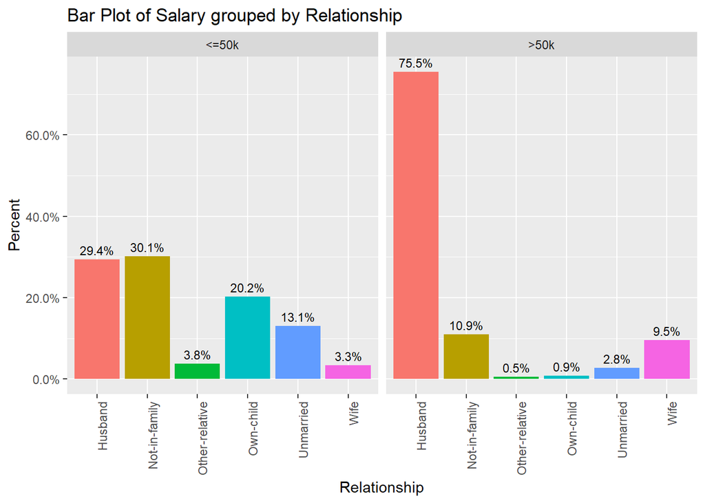

```r
ggplot(adult, aes(x=relationship,  group=salary)) +
    geom_bar(aes(y = ..prop.., fill = factor(..x..)), stat="count") +
    geom_text(aes( label = scales::percent(..prop..),
                   y= ..prop.. ), stat= "count", vjust = -.5,size=3) +
    labs(y = "Percent", fill="Relationship",x = "Relationship") +
    facet_grid(~salary) +
    scale_y_continuous(labels = scales::percent)+theme(legend.position = 'none',axis.text.x = element_text( hjust = 1,angle=90))+ggtitle("Bar Plot of Salary grouped by Relationship")
```

```r
# Number of people having different relationship with others earning less than 50K and more than 50K:
table(adult$relationship,adult$salary)
```

```
##
##                   <=50k >50k
##    Husband         7275 5918
##    Not-in-family   7449  856
##    Other-relative   944   37
##    Own-child       5001   67
##    Unmarried       3228  218
##    Wife             823  745
```

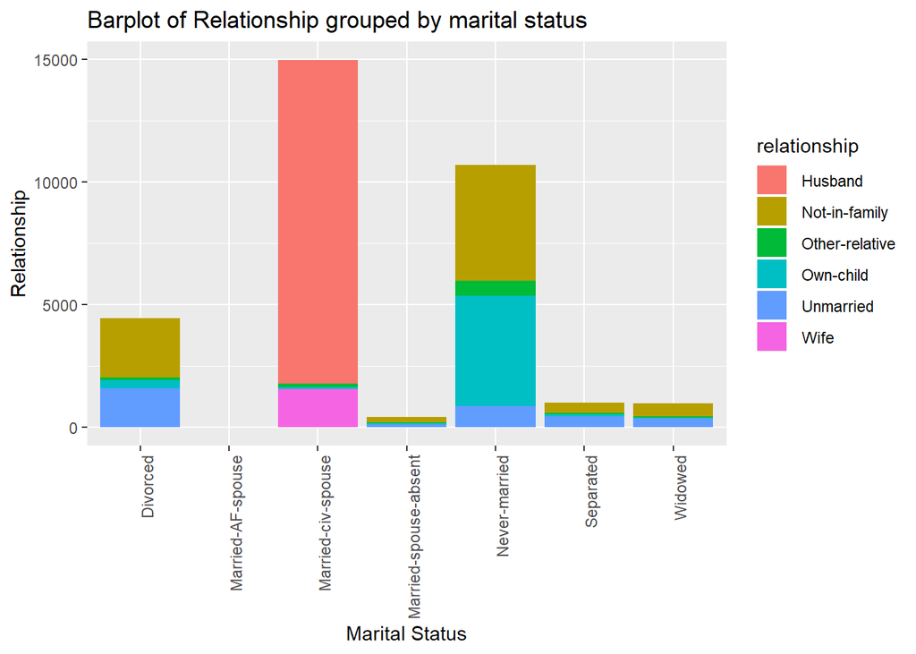

```r
ggplot(data = adult, mapping = aes(x = adult$maritalstatus,fill=relationship)) + geom_bar()  +ggtitle("Barplot of Relationship grouped by marital status")+theme(axis.text.x = element_text( hjust = 1,angle=90))+labs(x="Marital Status",y="Relationship")
```

- Relationship is closely realted to the variable " marital status" and they should be considered together. All the individuals of the category" Not-in-family" have a proper marital status, i.e. " Divorced“,” Married-spouse-absent“,” Never-married“,” Separated" or " Widowed“. The situation is similar with the categories” Husband" and " Wife“, where there are no discrepancies between their marital and relationship status.Another interesting observation that can be made is that people with marital status” Never-married" recognized themselves as belonging to one of the four relationship categories - " Not-in-family“,” Unmarried“,” Other-relative" and " Own-child“.

### Test for Independence of Relationship and salary.

- Null Hypothesis- Relationship and salary are independent in the considered population.
- Alternate Hypothesis -Relationship and salary are dependent in the considered population.

```r
chisq.test(adult$relationship,adult$salary,correct = FALSE)
```

```
##
##  Pearson's Chi-squared test
##
## data:  adult$relationship and adult$salary
## X-squared = 6699.1, df = 5, p-value < 2.2e-16
```

- The p-value is less than 0.05, which means that at the 0.05 significance level we fail to accept the null hypothesis that the two categorical variables are independent.Hence ,Relationship and salary are dependent on eachother.So,we can use Relationship as one of the feature in training for the prediction of salary.

### Analysis of Race and salary

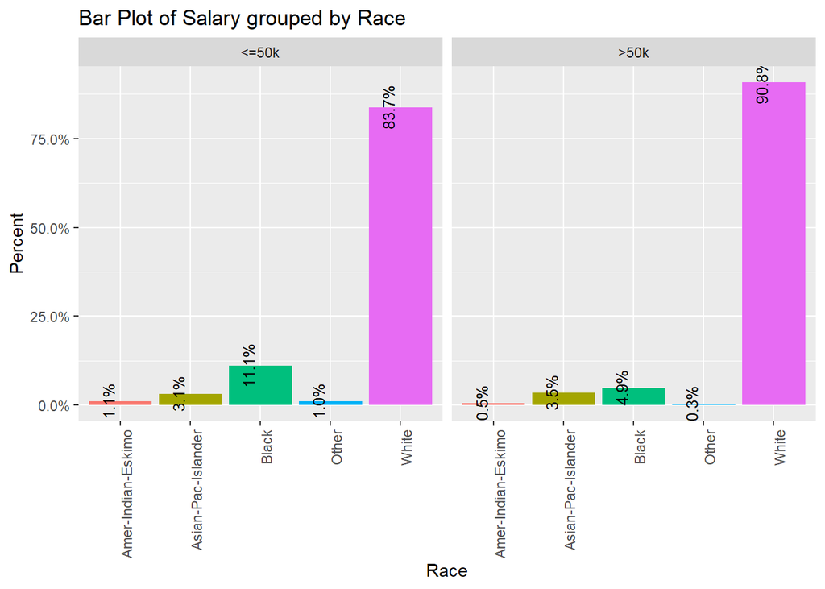

```r
ggplot(adult, aes(x=race,  group=salary)) +
    geom_bar(aes(y = ..prop.., fill = factor(..x..)), stat="count") +
    geom_text(aes( label = scales::percent(..prop..),
                   y= ..prop.. ), stat= "count", vjust = -.5,size=3.4,angle=90) +
    labs(y = "Percent", fill="Racep",x = "Race") +
    facet_grid(~salary) +
    scale_y_continuous(labels = scales::percent)+theme(legend.position = 'none',axis.text.x = element_text( hjust = 1,angle=90))+ggtitle("Bar Plot of Salary grouped by Race")
```

- The ratio between white and black people earning less than 50k is about 8% whereas this ratio grows to 18% for people earning greater than 50k per year.This difference in ratio shows more white people earn >50k.

```r
# Number of people from different "race" earning less than 50K and more than 50K:
table(adult$race,adult$salary)
```

```
##
##                       <=50k  >50k
##    Amer-Indian-Eskimo   275    36
##    Asian-Pac-Islander   763   276
##    Black               2737   387
##    Other                246    25
##    White              20699  7117
```

### Test for Independence of Race and salary.

- Null Hypothesis- Race and salary are independent in the considered population.
- Alternate Hypothesis -Race and salary are dependent in the considered population.

```r
chisq.test(adult$race,adult$salary,correct = FALSE)
```

```
##
##  Pearson's Chi-squared test
##
## data:  adult$race and adult$salary
## X-squared = 330.92, df = 4, p-value < 2.2e-16
```

- The p-value is less than 0.05, which means that at the 0.05 significance level we fail to accept the null hypothesis that the two categorical variables are independent.Hence ,Race and salary are dependent on eachother.So,we can use Race as one of the feature in training for the prediction of salary.

### Analysis of sex and salary

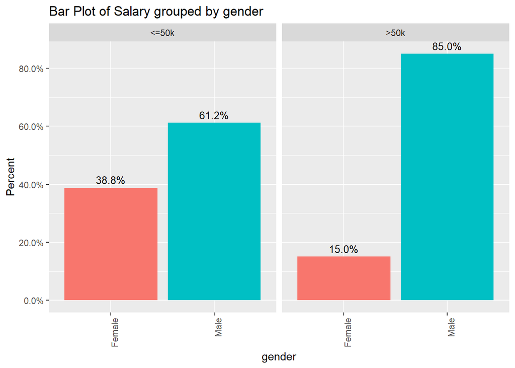

```r
ggplot(adult, aes(x=sex,  group=salary)) +
    geom_bar(aes(y = ..prop.., fill = factor(..x..)), stat="count") +
    geom_text(aes( label = scales::percent(..prop..),
                   y= ..prop.. ), stat= "count", vjust = -.5,size=3.5) +
    labs(y = "Percent", fill="gender",x = "gender") +
    facet_grid(~salary) +
    scale_y_continuous(labels = scales::percent)+theme(legend.position = 'none',axis.text.x = element_text( hjust = 1,angle=90))+ggtitle("Bar Plot of Salary grouped by gender")
```

- The ratio of male to female who are earning less than 50k is just 1.5 whereas this ratio grows 5.6 for male to female earning greater than 50k.Females earning >50k is very less due to less years of education or less working hours than men.

```r
# Number of men and women earning less than 50K and more than 50K:
table(adult$sex,adult$salary)
```

```
##
##           <=50k  >50k
##    Female  9592  1179
##    Male   15128  6662
```

### Plot of Gender and education number

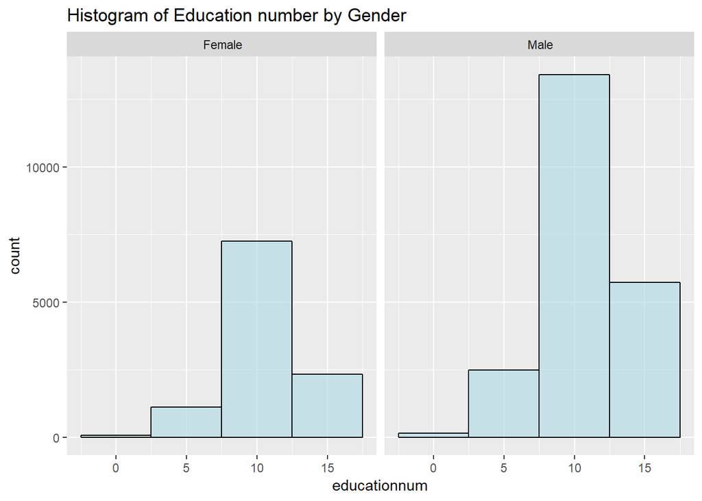

```r
ggplot(data = adult, mapping = aes(x = educationnum)) + geom_histogram(binwidth = 5,color = "black",fill = "lightblue",alpha = 0.6) +scale_x_continuous(breaks = seq(0, 95, 5)) +  facet_wrap(~sex) +ggtitle("Histogram of Education number by Gender")
```

### Test for Independence of Gender and salary.

- Null Hypothesis- Gender and salary are independent in the considered population.
- Alternate Hypothesis -Gender and salary are dependent in the considered population.

```r
chisq.test(adult$sex,adult$salary,correct = FALSE)
```

```
##
##  Pearson's Chi-squared test
##
## data:  adult$sex and adult$salary
## X-squared = 1518.9, df = 1, p-value < 2.2e-16
```

- The p-value is less than 0.05, which means that at the 0.05 significance level we fail to accept the null hypothesis that the two categorical variables are independent.Hence ,Gender and salary are dependent on eachother.So,we can use Gender as one of the feature in training for the prediction of salary.

### Analysis of Capital Gain and salary

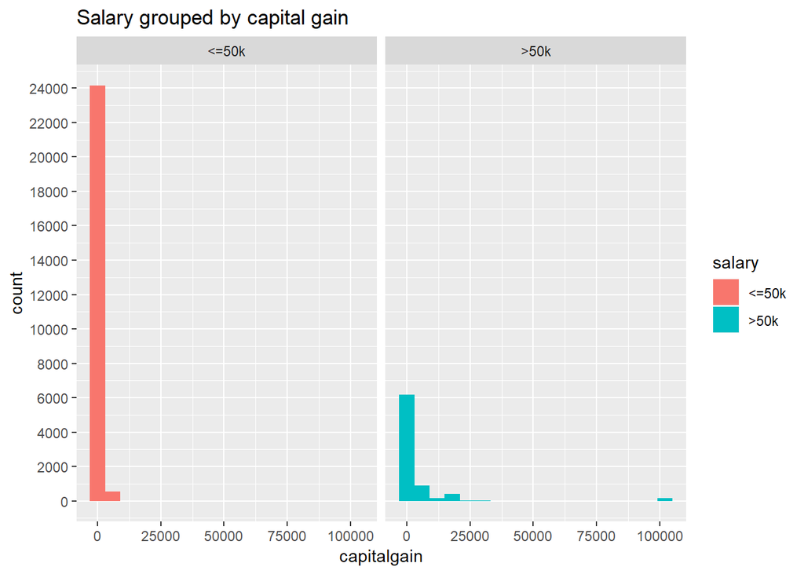

```r
ggplot(adult,aes(x=capitalgain,fill=salary))+geom_histogram(position="dodge",binwidth = 6000)+scale_y_continuous(breaks = seq(0, 30000, 2000))+ggtitle("Salary grouped by capital gain")+facet_wrap(~salary)
```

- Capital gain have very few unique values, although majority of their instances have zero values. This implies that very few people had capital gain whether they earn >50k or less than 50k,that shows capital gain doesnot have significant affect on distribution of salary.

### Analysis of Capital loss and salary

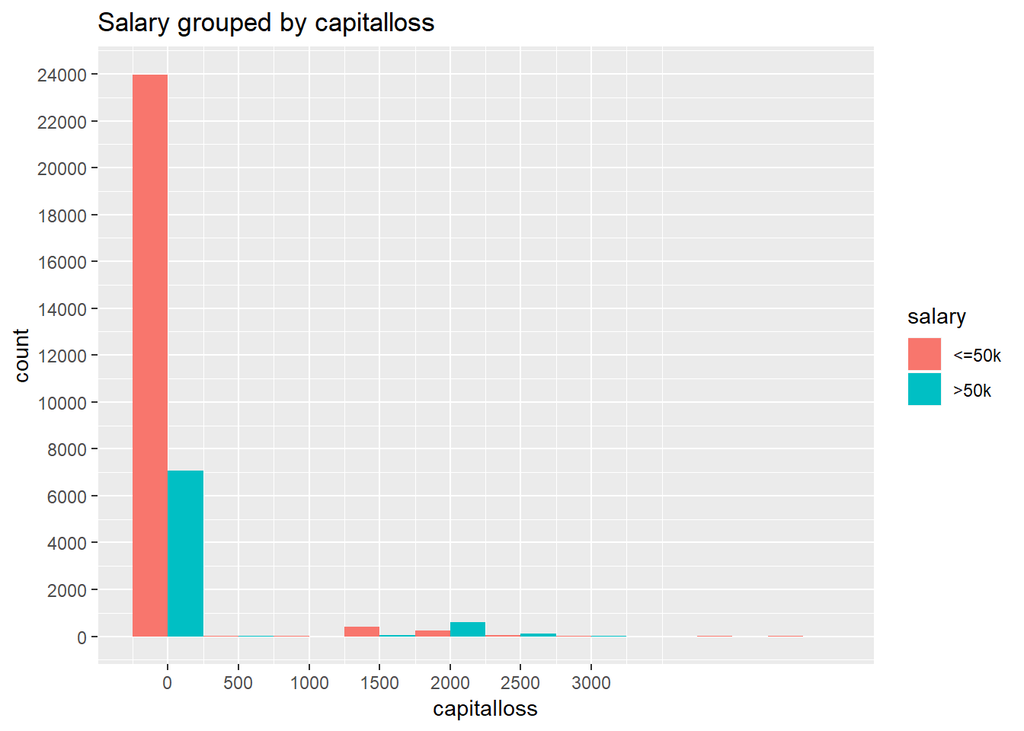

```r
ggplot(adult,aes(x=capitalloss,fill=salary))+geom_histogram(binwidth = 500,position="dodge")+scale_y_continuous(breaks = seq(0, 30000, 2000))+
scale_x_continuous(breaks = seq(0, 3000, 500))+ggtitle("Salary grouped by capitalloss")
```

- Capital loss also have very few unique values, although majority of their instances have zero values. This implies that very few people had capital loss whether they earn >50k or less than 50k,that shows capital loss doesnot have significant affect on distribution of salary.

### Analysis of Hours per week and salary

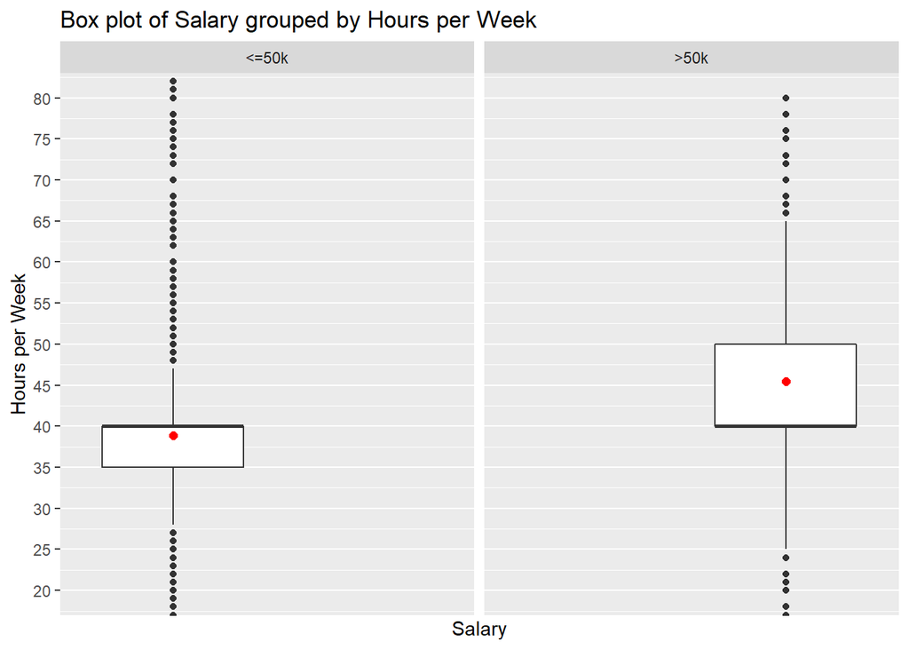

```r
ggplot(aes(x = salary, y = hoursperweek),data = adult) +geom_boxplot() +stat_summary(fun.y = mean,geom = "point", shape = 19,color = "red",cex = 2) +coord_cartesian(ylim = c(20, 80)) +scale_x_discrete(breaks = NULL) +scale_y_continuous(breaks = seq(20,80, 5)) + ylab("Hours per Week") +xlab("Salary") +  facet_wrap(.~salary)+ggtitle("Box plot of Salary grouped by Hours per Week")
```

- People who earn less than 50k a year works for 40 hours on an average in a week whereas average working hours of people earning >50k is 45.Thus we can say people who work for more number of hours in a week earns more than 50k whereas people who work for less hours in a week earns less than 50k per year.Ususally people who are studying or who are of older age or women works for less hours in a week thus they earn less than 50k.
- Even there are people who are working for more 50 hours to about 80 hours but still earns <=50k whereas there are people who works for <27 hours a week but still earn <=50k.
- There are people who have to work for more than 65 hours to earn >50k per year.
- Some people works for less than 27 hours but still earns >50k a year which shows the impact of more education and experience.

### Analysis of hours per week and gender

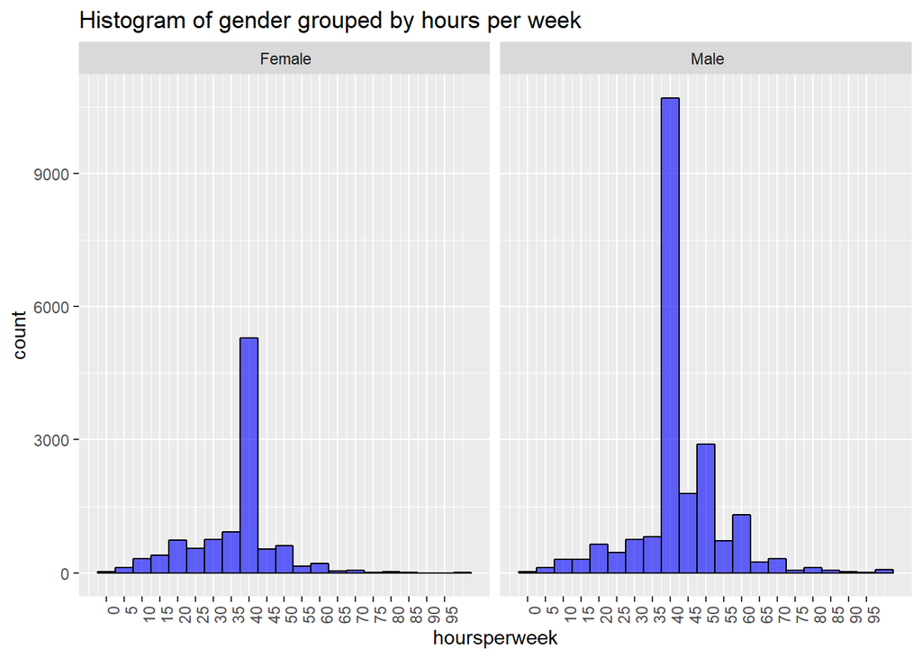

```r
ggplot(data = adult, mapping = aes(x = hoursperweek)) + geom_histogram(binwidth = 5,color = "black",fill = "blue",alpha = 0.6) +scale_x_continuous(breaks = seq(0, 95, 5)) +  facet_wrap(~sex) +ggtitle("Histogram of gender grouped by hours per week")+theme(legend.position = 'none',axis.text.x = element_text( hjust = 1,angle=90))
```

### Analysis of Native country and salary

### Test for Independence of Native country and salary.

- Null Hypothesis- Native country and salary are independent in the considered population.
- Hypothesis -Native country and salary are dependent in the considered population.

```r
chisq.test(adult$nativecountry,adult$salary,correct = FALSE)
```

```
##
##  Pearson's Chi-squared test
##
## data:  adult$nativecountry and adult$salary
## X-squared = 317.16, df = 40, p-value < 2.2e-16
```

- The p-value is less than 0.05, which means that at the 0.05 significance level we fail to accept the null hypothesis that the two categorical variables are independent.Hence ,Native country and salary are dependent on eachother.So,we can use Native country as one of the feature in training for the prediction of salary.

```r
#Number of people earning less than 50k and more than 50k from different native region.
table(adult$nativecountry,adult$salary)
```

```
##
##                               <=50k  >50k
##    ?                              0     0
##    Cambodia                      12     7
##    Canada                        82    39
##    China                         55    20
##    Columbia                      57     2
##    Cuba                          70    25
##    Dominican-Republic            68     2
##    Ecuador                       24     4
##    El-Salvador                   97     9
##    England                       60    30
##    France                        17    12
##    Germany                       93    44
##    Greece                        21     8
##    Guatemala                     61     3
##    Haiti                         40     4
##    Holand-Netherlands             1     0
##    Honduras                      12     1
##    Hong                          14     6
##    Hungary                       10     3
##    India                         60    40
##    Iran                          25    18
##    Ireland                       19     5
##    Italy                         48    25
##    Jamaica                       71    10
##    Japan                         38    24
##    Laos                          16     2
##    Mexico                       610    33
##    Nicaragua                     32     2
##    Outlying-US(Guam-USVI-etc)    14     0
##    Peru                          29     2
##    Philippines                  137    61
##    Poland                        48    12
##    Portugal                      33     4
##    Puerto-Rico                  102    12
##    Scotland                       9     3
##    South                         64    16
##    Taiwan                        31    20
##    Thailand                      15     3
##    Trinadad&Tobago               17     2
##    United-States              22436  7317
##    Vietnam                       62     5
##    Yugoslavia                    10     6
```

## Conclusion from Analysis of Bivariate Distribution

- Salary of people depends on age.People earning <50k are of age group 20 to 37 years whereas people who earn >50k are of age group 37 to 55 years.
- Salary of people depends on workclass,education,marital status,occupation,gender,race,nativecountry as proved by chi-square test.
- People who earn more works for more than 45 hours.
- Male works for more hours than female.
- Capital gain and Capital loss doesnot have significant affect on salary.
- Majority of people who earn greater than 50k are married males.
- Salary increases with education and experience.

Go to top:Table of Contents

## Multivariate Distribution

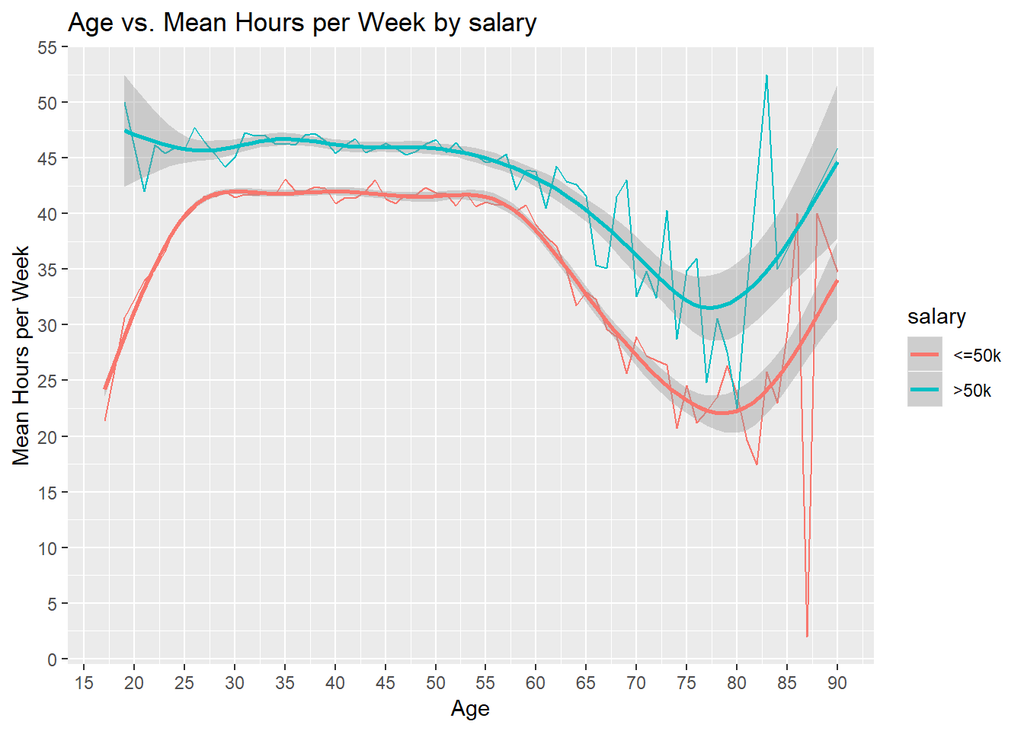

```r
ggplot(aes(x = age, y = hoursperweek),data = adult) + geom_line(mapping = aes(color = salary),stat = 'summary', fun.y = mean) + geom_smooth(mapping = aes(color = salary)) +scale_x_continuous(breaks = seq(10, 100, 5)) + scale_y_continuous(breaks = seq(0, 55, 5)) +
  labs(x = "Age", y = "Mean Hours per Week") +
  ggtitle("Age vs. Mean Hours per Week by salary")
```

```r
b1<-select(adult,hoursperweek,age,salary)
 b1<- group_by(b1,salary)
 b1<- summarise(b1,average_hours= mean(hoursperweek,rm.na=TRUE),average_age=       mean(age,rm.na=TRUE))
 b2<- select(b1,everything())
 b2
```

```
## # A tibble: 2 x 3
##   salary average_hours average_age
##   <fct>          <dbl>       <dbl>
## 1 <=50k           38.8        36.8
## 2 >50k            45.5        44.2
```

- Average working hours of people earning less than 50k is less that is 38.8 hours whereas people earning >50 works for more hours that is 45.4 hours in a week.
- Average age of people earning less than 50k is less that is 36.7 years whereas people who earn >50k are older that is average age is 44.2 years.
- People who earns more works for more hours and are older than the people who earns less.

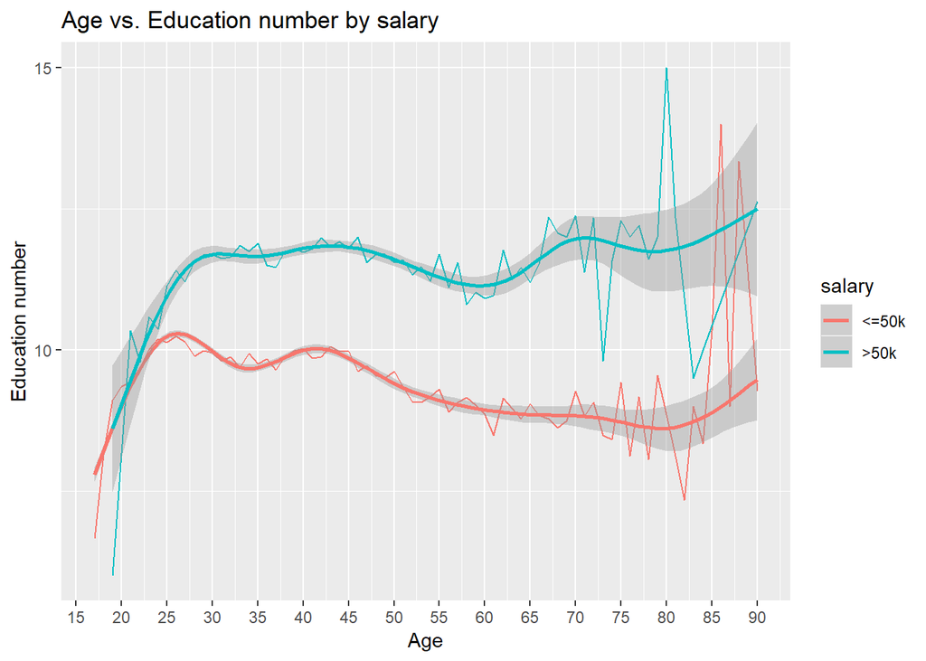

```r
ggplot(aes(x = age, y = educationnum),data = adult) + geom_line(mapping = aes(color = salary),stat = 'summary', fun.y = mean) + geom_smooth(mapping = aes(color = salary)) +scale_x_continuous(breaks = seq(10, 100, 5)) + scale_y_continuous(breaks = seq(0, 55, 5)) +
  labs(x = "Age", y = "Education number") +
  ggtitle("Age vs. Education number by salary")
```

```r
h1<-select(adult,educationnum,age,salary)
 h1<- group_by(h1,salary)
 h1<- summarise(h1,average_educationyears= mean(educationnum,rm.na=TRUE),average_age=       mean(age,rm.na=TRUE))
 h2<- select(h1,everything())
 h2
```

```
## # A tibble: 2 x 3
##   salary average_educationyears average_age
##   <fct>                   <dbl>       <dbl>
## 1 <=50k                    9.60        36.8
## 2 >50k                    11.6         44.2
```

- It is clearly visible from the table that people who earns <50k are educated less that is 9.5 years on an average.
- People who earn >50k per year are educated more that is 11.6 years on an average.
- Average is 36.7 years for people earning <=50k.
- Average age of people earning >50k is more that is 44.2 years.
- People who earn >50k are older and more educated than people who earn <50k.